# Software Tools for Earth and Environmental Science

– 12th WEEK –

Emir Toker

06/12/2019

## Ek ders

- Data Frame
- List
- Factor
- Table
- Structures and Attributes
- Netcdf Structure

Break

- Which
- apply Group
- Functions
- String Manipulation

# Data Frame

## Data Frame

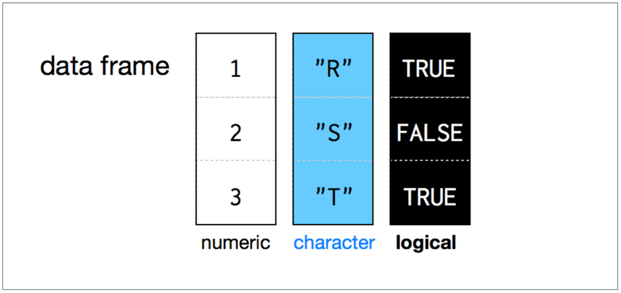

Heterojen, sütunların satır sayısı birbirine eşit

## Data Frame

```r
v1 <- c("ahmet","mehmet","hüseyin")
v2 <- c( TRUE, FALSE, FALSE)
m1 <- matrix(1:6 , 3, 2)

df1 <- data.frame(v1,v2,m1)
df1
```

```
##        v1    v2 X1 X2
## 1   ahmet  TRUE  1  4
## 2  mehmet FALSE  2  5
## 3 hüseyin FALSE  3  6
```

```
df1[1]
df1[[1]]
str(df1)

df1 <- data.frame(v1,v2,m1,stringsAsFactors = F)
df1[1]
df1[[1]]
str(df1)
df1$v1
```

## Data Frame

```r
df1
```

```
##        v1    v2 X1 X2
## 1   ahmet  TRUE  1  4
## 2  mehmet FALSE  2  5
## 3 hüseyin FALSE  3  6
```

```
df1[1:4]
df1[1:4,3]
df1[1:6,3]
df1[3,1:4]
```

```r
df1$v2
```

```
## [1]  TRUE FALSE FALSE
```

```
as.character(df1$v2)
df1$v2
df1$v2 <- as.character(df1$v2)
as.numeric(df1$v2)
```

## Data Frame

```r
attributes(df1)
```

```
## $names
## [1] "v1" "v2" "X1" "X2"
##
## $class
## [1] "data.frame"
##
## $row.names
## [1] 1 2 3
```

```
attributes(df1)$names
attr(df1,"names")

attr(df1,"names") <- c("isim","logic","sayi1","sayi2")
df1
attr(df1,"$row.names") <- c("a","b","c")
df1
```

## Data Frame

```r
read.csv("https://web.itu.edu.tr/~tokerem/18397_Cekmekoy_Omerli_15dk.txt")
```

```
##     sta_no.year.month.day.hour.minutes.temp.precipitation.pressure.relative_humidity
## 1                                                18397;2017;7;26;18;0;23.9;0;1003;94
## 2                                             18397;2017;7;26;18;15;23.9;0;1003.1;95
## 3                                             18397;2017;7;26;18;30;23.8;0;1003.2;96
## 4                                             18397;2017;7;26;18;45;23.8;0;1003.2;96
## 5                                              18397;2017;7;26;19;0;23.6;0;1003.2;96
## 6                                             18397;2017;7;26;19;15;23.2;0;1003.1;97
## 7                                             18397;2017;7;26;19;30;23.2;0;1003.1;97
## 8                                             18397;2017;7;26;19;45;23.1;0;1003.1;98
## 9                                                18397;2017;7;26;20;0;23;0;1003.1;98
## 10                                              18397;2017;7;26;20;15;22.8;0;1003;98
## 11                                              18397;2017;7;26;20;30;22.5;0;1003;98
## 12                                              18397;2017;7;26;20;45;22.4;0;1003;99
## 13                                               18397;2017;7;26;21;0;22.2;0;1003;99
## 14                                              18397;2017;7;26;21;15;22.3;0;1003;99
```

[output cut: 107 more lines]

## Data Frame

```r
read.csv("https://web.itu.edu.tr/~tokerem/18397_Cekmekoy_Omerli_15dk.txt", sep = ";")
```

```
##     sta_no year month day hour minutes temp precipitation pressure
## 1    18397 2017     7  26   18       0 23.9          0.00   1003.0
## 2    18397 2017     7  26   18      15 23.9          0.00   1003.1
## 3    18397 2017     7  26   18      30 23.8          0.00   1003.2
## 4    18397 2017     7  26   18      45 23.8          0.00   1003.2
## 5    18397 2017     7  26   19       0 23.6          0.00   1003.2
## 6    18397 2017     7  26   19      15 23.2          0.00   1003.1
## 7    18397 2017     7  26   19      30 23.2          0.00   1003.1
## 8    18397 2017     7  26   19      45 23.1          0.00   1003.1
## 9    18397 2017     7  26   20       0 23.0          0.00   1003.1
## 10   18397 2017     7  26   20      15 22.8          0.00   1003.0
## 11   18397 2017     7  26   20      30 22.5          0.00   1003.0
## 12   18397 2017     7  26   20      45 22.4          0.00   1003.0
## 13   18397 2017     7  26   21       0 22.2          0.00   1003.0
## 14   18397 2017     7  26   21      15 22.3          0.00   1003.0
```

[output cut: 229 more lines]

```r
sta1 <- read.csv("https://web.itu.edu.tr/~tokerem/18397_Cekmekoy_Omerli_15dk.txt", sep = ";")
```

## Data Frame

```r
str(sta1)
```

```
## 'data.frame':    121 obs. of  10 variables:
##  $ sta_no           : int  18397 18397 18397 18397 18397 18397 18397 18397 18397 18397 ...
##  $ year             : int  2017 2017 2017 2017 2017 2017 2017 2017 2017 2017 ...
##  $ month            : int  7 7 7 7 7 7 7 7 7 7 ...
##  $ day              : int  26 26 26 26 26 26 26 26 26 26 ...
##  $ hour             : int  18 18 18 18 19 19 19 19 20 20 ...
##  $ minutes          : int  0 15 30 45 0 15 30 45 0 15 ...
##  $ temp             : num  23.9 23.9 23.8 23.8 23.6 23.2 23.2 23.1 23 22.8 ...
##  $ precipitation    : num  0 0 0 0 0 0 0 0 0 0 ...
##  $ pressure         : num  1003 1003 1003 1003 1003 ...
##  $ relative_humidity: int  94 95 96 96 96 97 97 98 98 98 ...
```

## Data Frame

```r
attributes(sta1)
```

```
## $names
##  [1] "sta_no"            "year"              "month"
##  [4] "day"               "hour"              "minutes"
##  [7] "temp"              "precipitation"     "pressure"
## [10] "relative_humidity"
##
## $class
## [1] "data.frame"
##
## $row.names
##   [1]   1   2   3   4   5   6   7   8   9  10  11  12  13  14  15  16  17
##  [18]  18  19  20  21  22  23  24  25  26  27  28  29  30  31  32  33  34
##  [35]  35  36  37  38  39  40  41  42  43  44  45  46  47  48  49  50  51
##  [52]  52  53  54  55  56  57  58  59  60  61  62  63  64  65  66  67  68
##  [69]  69  70  71  72  73  74  75  76  77  78  79  80  81  82  83  84  85
##  [86]  86  87  88  89  90  91  92  93  94  95  96  97  98  99 100 101 102
## [103] 103 104 105 106 107 108 109 110 111 112 113 114 115 116 117 118 119
## [120] 120 121
```

## Data Frame

```r
sta1[25:121,2:10]
```

```
##     year month day hour minutes temp precipitation pressure
## 25  2017     7  27    0       0 22.3          0.00   1003.4
## 26  2017     7  27    0      15 22.2          0.00   1003.2
## 27  2017     7  27    0      30 22.5          0.00   1003.2
## 28  2017     7  27    0      45 22.6          0.00   1003.2
## 29  2017     7  27    1       0 22.6          0.00   1003.3
## 30  2017     7  27    1      15 22.6          0.00   1003.4
## 31  2017     7  27    1      30 22.6          0.00   1003.2
## 32  2017     7  27    1      45 22.7          0.00   1003.2
## 33  2017     7  27    2       0 22.6          0.00   1003.3
## 34  2017     7  27    2      15 22.5          0.00   1003.2
## 35  2017     7  27    2      30 22.6          0.00   1003.2
## 36  2017     7  27    2      45 22.5          0.00   1003.1
## 37  2017     7  27    3       0 22.5          0.00   1003.1
## 38  2017     7  27    3      15 22.4          0.00   1003.0
```

[output cut: 181 more lines]

```r
sta2 <- sta1[25:121,2:10]
```

## Data Frame

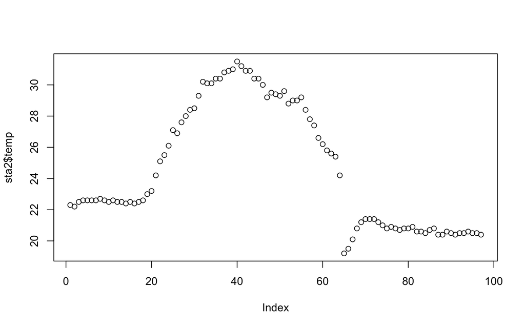

```r
plot(sta2$temp)
```

## Data Frame

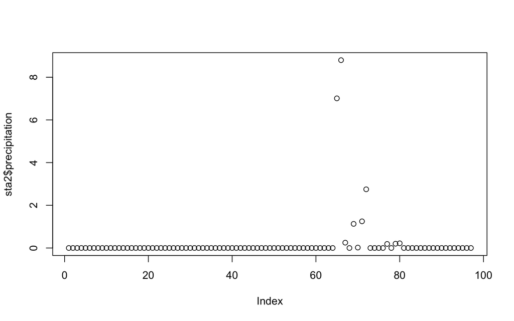

```r
plot(sta2$precipitation)
```

## Data Frame

```r
sta2$temp<20
```

```
##  [1] FALSE FALSE FALSE FALSE FALSE FALSE FALSE FALSE FALSE FALSE FALSE
## [12] FALSE FALSE FALSE FALSE FALSE FALSE FALSE FALSE FALSE FALSE FALSE
## [23] FALSE FALSE FALSE FALSE FALSE FALSE FALSE FALSE FALSE FALSE FALSE
## [34] FALSE FALSE FALSE FALSE FALSE FALSE FALSE FALSE FALSE FALSE FALSE
## [45] FALSE FALSE FALSE FALSE FALSE FALSE FALSE FALSE FALSE FALSE FALSE
## [56] FALSE FALSE FALSE FALSE FALSE FALSE FALSE FALSE FALSE  TRUE  TRUE
## [67] FALSE FALSE FALSE FALSE FALSE FALSE FALSE FALSE FALSE FALSE FALSE
## [78] FALSE FALSE FALSE FALSE FALSE FALSE FALSE FALSE FALSE FALSE FALSE
## [89] FALSE FALSE FALSE FALSE FALSE FALSE FALSE FALSE FALSE
```

```r
which(sta2$temp<20)
```

```
## [1] 65 66
```

```r
temp_min_indis <- which(sta2$temp<20)
```

## Data Frame

```r
temp_min_indis
```

```
## [1] 65 66
```

```r
sta2$precipitation[temp_min_indis]
```

```
## [1] 7.01 8.80
```

```r
sta2$precipitation[sta2$temp<20]
```

```
## [1] 7.01 8.80
```

```r
max(sta2$precipitation)
```

```
## [1] 8.8
```

## Data Frame

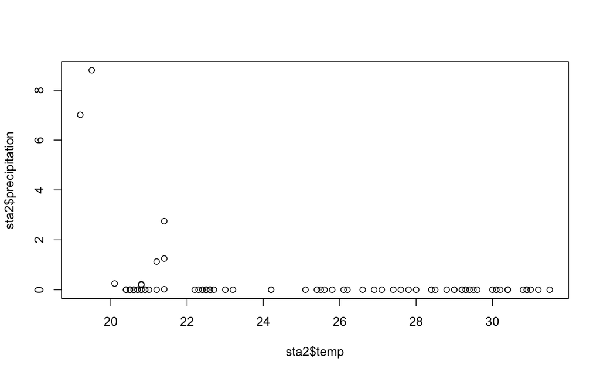

```r
plot(sta2$temp,sta2$precipitation)
```

## Data Frame

```r
cov(sta2$temp,sta2$precipitation)
```

```
## [1] -1.078493
```

```r
cor(sta2$temp,sta2$precipitation)
```

```
## [1] -0.2345707
```

# List

## List

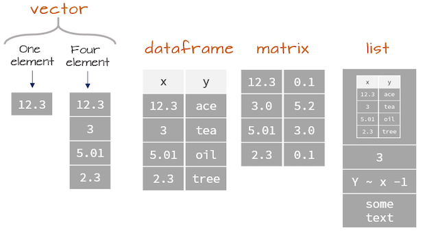

## List

```r
v1 <- c("ahmet","mehmet","hüseyin")
v2 <- c( TRUE, FALSE, FALSE)
m1 <- matrix(1:6 , 3, 2)
df1 <- data.frame(v1,v2,m1)

l1 <- list(v1,v2,m1,df1)
l1
```

```
## [[1]]
## [1] "ahmet"   "mehmet"  "hüseyin"
##
## [[2]]
## [1]  TRUE FALSE FALSE
##
## [[3]]
##      [,1] [,2]
## [1,]    1    4
## [2,]    2    5
## [3,]    3    6
##
## [[4]]
##        v1    v2 X1 X2
## 1   ahmet  TRUE  1  4
## 2  mehmet FALSE  2  5
## 3 hüseyin FALSE  3  6
```

## List

```r
l1[1]
```

```
## [[1]]
## [1] "ahmet"   "mehmet"  "hüseyin"
```

```r
l1[1][1]
```

```
## [[1]]
## [1] "ahmet"   "mehmet"  "hüseyin"
```

```r
l1[[1]]
```

```
## [1] "ahmet"   "mehmet"  "hüseyin"
```

```r
l1[[1]][1]
```

```
## [1] "ahmet"
```

## List

```r
l1[1:2]
```

```
## [[1]]
## [1] "ahmet"   "mehmet"  "hüseyin"
##
## [[2]]
## [1]  TRUE FALSE FALSE
```

```
l1[1:2,2:3]
```

```r
str(l1)
```

```
## List of 4
##  $ : chr [1:3] "ahmet" "mehmet" "hüseyin"
##  $ : logi [1:3] TRUE FALSE FALSE
##  $ : int [1:3, 1:2] 1 2 3 4 5 6
##  $ :'data.frame':    3 obs. of  4 variables:
##   ..$ v1: Factor w/ 3 levels "ahmet","hüseyin",..: 1 3 2
##   ..$ v2: logi [1:3] TRUE FALSE FALSE
##   ..$ X1: int [1:3] 1 2 3
##   ..$ X2: int [1:3] 4 5 6
```

## List

```r
attributes(l1)
```

```r
l1[4]
```

```
## [[1]]
##        v1    v2 X1 X2
## 1   ahmet  TRUE  1  4
## 2  mehmet FALSE  2  5
## 3 hüseyin FALSE  3  6
```

```
df2 <- l1[4]
df2

df2 <- l1[[4]]
df2
```

# Factor

## Factor

```r
char1 <- c("a","b","c","a","d","d","a")
fac1 <- factor(char1)
fac1
```

```
## [1] a b c a d d a
## Levels: a b c d
```

```r
fac1[4]
```

```
## [1] a
## Levels: a b c d
```

```r
num1 <- c(1,4,2,5,7,3,2,1,1,1,2)
fac2 <- factor(num1)
fac2
```

```
##  [1] 1 4 2 5 7 3 2 1 1 1 2
## Levels: 1 2 3 4 5 7
```

# Table

## Table

```r
char1 <- c("a","b","c","a","d","d","a")
tab1 <- table(char1)
tab1
```

```
## char1
## a b c d
## 3 1 1 2
```

```r
tab1[2]
```

```
## b
## 1
```

```r
num1 <- c(1,4,2,5,7,3,2,1,1,1,2)
tab2 <- table(num1)
tab2
```

```
## num1
## 1 2 3 4 5 7
## 4 3 1 1 1 1
```

# Netcdf Structure

## Netcdf Structure

[LINK](https://emirtoker.github.io/Software_Tools_R_Github/netcdf.html)

# Break

# Which

```r
which(letters == "g")
```

```
## [1] 7
```

```r
num1 <- c(1,4,2,5,7,3,2,1,1,1,2)
which(num1 != 1)
```

```
## [1]  2  3  4  5  6  7 11
```

```r
which(num1 != c(1,2))
```

```
## [1]  2  3  4  5  6  7  8 10 11
```

```r
which(num1 != 1 & num1 != 2)
```

```
## [1] 2 4 5 6
```

```r
head(sta1)
```

```
##   sta_no year month day hour minutes temp precipitation pressure
## 1  18397 2017     7  26   18       0 23.9             0   1003.0
## 2  18397 2017     7  26   18      15 23.9             0   1003.1
## 3  18397 2017     7  26   18      30 23.8             0   1003.2
## 4  18397 2017     7  26   18      45 23.8             0   1003.2
## 5  18397 2017     7  26   19       0 23.6             0   1003.2
## 6  18397 2017     7  26   19      15 23.2             0   1003.1
##   relative_humidity
## 1                94
## 2                95
## 3                96
## 4                96
## 5                96
## 6                97
```

```r
which((sta1$hour == 18) & (sta1$minutes == 15))
```

```
## [1]  2 98
```

```r
m2 <- matrix(1:16,4,4)
m2
```

```
##      [,1] [,2] [,3] [,4]
## [1,]    1    5    9   13
## [2,]    2    6   10   14
## [3,]    3    7   11   15
## [4,]    4    8   12   16
```

```r
which.min(m2)
```

```
## [1] 1
```

```r
which(m2-7 > 0)
```

```
## [1]  8  9 10 11 12 13 14 15 16
```

```r
which(m2-7 > 0, arr.ind=TRUE)
```

```
##       row col
##  [1,]   4   2
##  [2,]   1   3
##  [3,]   2   3
##  [4,]   3   3
##  [5,]   4   3
##  [6,]   1   4
##  [7,]   2   4
##  [8,]   3   4
##  [9,]   4   4
```

```r
which(m2-7 > 0, arr.ind=TRUE, useNames = FALSE)
```

```
##       [,1] [,2]
##  [1,]    4    2
##  [2,]    1    3
##  [3,]    2    3
##  [4,]    3    3
##  [5,]    4    3
##  [6,]    1    4
##  [7,]    2    4
##  [8,]    3    4
##  [9,]    4    4
```

```r
which(ll <- c(TRUE, FALSE, TRUE, NA, FALSE, FALSE, TRUE))
```

```
## [1] 1 3 7
```

```r
ll
```

```
## [1]  TRUE FALSE  TRUE    NA FALSE FALSE  TRUE
```

```r
seq(ll)
```

```
## [1] 1 2 3 4 5 6 7
```

```r
letters[seq(ll)]
```

```
## [1] "a" "b" "c" "d" "e" "f" "g"
```

# apply Group

## apply

apply(X, MARGIN, FUN)

**takes data frame or matrix as an input**

- **x**: an array or matrix
- **MARGIN**: take a value or range between 1 and 2 to define where to apply the function:
  - **MARGIN**=1`: the manipulation is performed on rows
  - **MARGIN**=2`: the manipulation is performed on columns
  - **MARGIN**=c(1,2)` the manipulation is performed on rows and columns
- **FUN**: tells which function to apply. Built functions like mean, median, sum, min, max..

**gives output in vector, list or array**

## apply

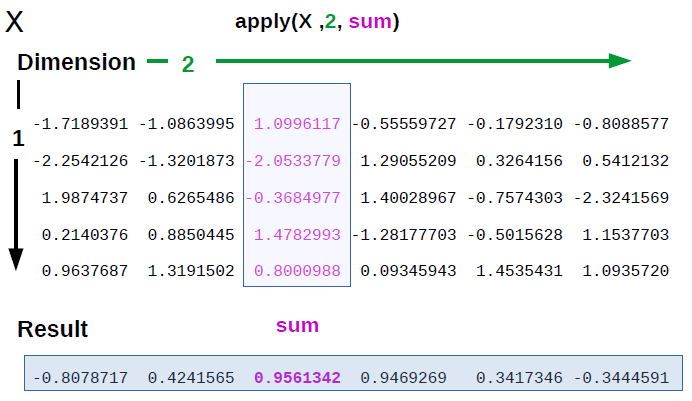

## apply

```r
m1 <- matrix( 1:10 , nrow=5, ncol=6)
m1
```

```
##      [,1] [,2] [,3] [,4] [,5] [,6]
## [1,]    1    6    1    6    1    6
## [2,]    2    7    2    7    2    7
## [3,]    3    8    3    8    3    8
## [4,]    4    9    4    9    4    9
## [5,]    5   10    5   10    5   10
```

```r
a_m1 <- apply(m1, 2, sum)
a_m1
```

```
## [1] 15 40 15 40 15 40
```

## apply

```r
a_m1
```

```
## [1] 15 40 15 40 15 40
```

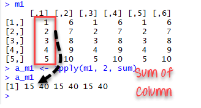

## lapply

lapply(X, FUN)

**takes list, vector or data frame as input**

- **X**: A vector or an object
- **FUN**: Function applied to each element of x

lapply() function does not need MARGIN

**gives output in list**

## lapply

```r
v1
```

```
## [1] "ahmet"   "mehmet"  "hüseyin"
```

```r
lapply(v1,max)
```

```
## [[1]]
## [1] "ahmet"
##
## [[2]]
## [1] "mehmet"
##
## [[3]]
## [1] "hüseyin"
```

## lapply

```r
l1
```

```
## [[1]]
## [1] "ahmet"   "mehmet"  "hüseyin"
##
## [[2]]
## [1]  TRUE FALSE FALSE
##
## [[3]]
##      [,1] [,2]
## [1,]    1    4
## [2,]    2    5
## [3,]    3    6
##
## [[4]]
##        v1    v2 X1 X2
## 1   ahmet  TRUE  1  4
## 2  mehmet FALSE  2  5
## 3 hüseyin FALSE  3  6
```

## lapply

```r
#l1
lapply(l1, FUN = dim)
```

```
## [[1]]
## NULL
##
## [[2]]
## NULL
##
## [[3]]
## [1] 3 2
##
## [[4]]
## [1] 3 4
```

## lapply

```r
#l1
lapply(l1,"[",1)
```

```
## [[1]]
## [1] "ahmet"
##
## [[2]]
## [1] TRUE
##
## [[3]]
## [1] 1
##
## [[4]]
##        v1
## 1   ahmet
## 2  mehmet
## 3 hüseyin
```

## lapply

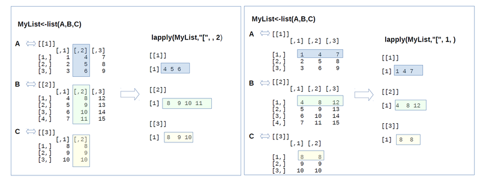

## lapply

```r
l2 <- list(x = 1:5, y = 6:10, z = 11:15)
lapply(l2, FUN = median)
```

```
## $x
## [1] 3
##
## $y
## [1] 8
##
## $z
## [1] 13
```

## lapply

```r
head(cars)
```

```
##   speed dist
## 1     4    2
## 2     4   10
## 3     7    4
## 4     7   22
## 5     8   16
## 6     9   10
```

```r
df3 <- cars

lapply(df3, min)
```

```
## $speed
## [1] 4
##
## $dist
## [1] 2
```

## sapply

sapply(X, FUN)

**takes list, vector or data frame as input**

- **X**: A vector or an object
- **FUN**: Function applied to each element of x

**gives output in vector or matrix**

## sapply

```r
#head(cars)
#df3 <- cars

lapply(df3, min)
```

```
## $speed
## [1] 4
##
## $dist
## [1] 2
```

```r
sapply(df3, min)
```

```
## speed  dist
##     4     2
```

## tapply

tapply(X, INDEX, FUN = NULL)

for each factor variable in a vector

- **X**: An object, usually a vector
- **INDEX**: A list containing factor
- **FUN**: Function applied to each element of x

## tapply

```r
iris
```

```
##     Sepal.Length Sepal.Width Petal.Length Petal.Width    Species
## 1            5.1         3.5          1.4         0.2     setosa
## 2            4.9         3.0          1.4         0.2     setosa
## 3            4.7         3.2          1.3         0.2     setosa
## 4            4.6         3.1          1.5         0.2     setosa
## 5            5.0         3.6          1.4         0.2     setosa
## 6            5.4         3.9          1.7         0.4     setosa
## 7            4.6         3.4          1.4         0.3     setosa
## 8            5.0         3.4          1.5         0.2     setosa
## 9            4.4         2.9          1.4         0.2     setosa
## 10           4.9         3.1          1.5         0.1     setosa
## 11           5.4         3.7          1.5         0.2     setosa
## 12           4.8         3.4          1.6         0.2     setosa
## 13           4.8         3.0          1.4         0.1     setosa
## 14           4.3         3.0          1.1         0.1     setosa
```

[output cut: 136 more lines]

## tapply

```r
tapply(iris$Sepal.Width, iris$Species, median)
```

```
##     setosa versicolor  virginica
##        3.4        2.8        3.0
```

## mapply

**mapply** - For when you have several data structures (e.g. vectors, lists) and you want to apply a function to the 1st elements of each, and then the 2nd elements of each

```r
sum(1:5, 1:5, 1:5)
```

```
## [1] 45
```

```r
rep(1:4, 4:1)   # replicates
```

```
##  [1] 1 1 1 1 2 2 2 3 3 4
```

## mapply

```r
mapply(sum, 1:5, 1:5, 1:5)
```

```
## [1]  3  6  9 12 15
```

```r
mapply(rep, 1:4, 4:1)   # replicates
```

```
## [[1]]
## [1] 1 1 1 1
##
## [[2]]
## [1] 2 2 2
##
## [[3]]
## [1] 3 3
##
## [[4]]
## [1] 4
```

## sweep

```r
m3 <- matrix(4:15,4,3)
m3
```

```
##      [,1] [,2] [,3]
## [1,]    4    8   12
## [2,]    5    9   13
## [3,]    6   10   14
## [4,]    7   11   15
```

```r
m3_mean <- apply(m3, 2, mean)
m3_mean
```

```
## [1]  5.5  9.5 13.5
```

```r
m3_sd <- apply(m3, 2, sd)
m3_sd
```

```
## [1] 1.290994 1.290994 1.290994
```

## sweep

```r
m3_a <- sweep(m3, 2, m3_mean,"-")
m3_a
```

```
##      [,1] [,2] [,3]
## [1,] -1.5 -1.5 -1.5
## [2,] -0.5 -0.5 -0.5
## [3,]  0.5  0.5  0.5
## [4,]  1.5  1.5  1.5
```

```r
m3_b <- sweep(m3_a, 2, m3_sd, "/")
m3_b
```

```
##            [,1]       [,2]       [,3]
## [1,] -1.1618950 -1.1618950 -1.1618950
## [2,] -0.3872983 -0.3872983 -0.3872983
## [3,]  0.3872983  0.3872983  0.3872983
## [4,]  1.1618950  1.1618950  1.1618950
```

## aggregate

```r
sta2
```

```
##     year month day hour minutes temp precipitation pressure
## 25  2017     7  27    0       0 22.3          0.00   1003.4
## 26  2017     7  27    0      15 22.2          0.00   1003.2
## 27  2017     7  27    0      30 22.5          0.00   1003.2
## 28  2017     7  27    0      45 22.6          0.00   1003.2
## 29  2017     7  27    1       0 22.6          0.00   1003.3
## 30  2017     7  27    1      15 22.6          0.00   1003.4
## 31  2017     7  27    1      30 22.6          0.00   1003.2
## 32  2017     7  27    1      45 22.7          0.00   1003.2
## 33  2017     7  27    2       0 22.6          0.00   1003.3
## 34  2017     7  27    2      15 22.5          0.00   1003.2
## 35  2017     7  27    2      30 22.6          0.00   1003.2
## 36  2017     7  27    2      45 22.5          0.00   1003.1
## 37  2017     7  27    3       0 22.5          0.00   1003.1
## 38  2017     7  27    3      15 22.4          0.00   1003.0
```

[output cut: 181 more lines]

## aggregate

```r
aggregate(sta2$temp, by=sta2["hour"], FUN=sum)
```

```
##    hour     x
## 1     0 110.0
## 2     1  90.5
## 3     2  90.2
## 4     3  89.8
## 5     4  91.3
## 6     5 100.9
## 7     6 109.6
## 8     7 116.4
## 9     8 121.0
## 10    9 124.2
## 11   10 123.4
## 12   11 119.1
## 13   12 117.1
## 14   13 115.6
## 15   14 108.0
## 16   15 101.0
## 17   16  79.6
## 18   17  85.4
## 19   18  83.9
## 20   19  83.1
## 21   20  82.6
## 22   21  82.3
## 23   22  82.0
## 24   23  82.1
```

# Functions

## Functions

```r
celsius_to_kelvin <- function(temp_C) {
  temp_K <- temp_C + 273.15
  return(temp_K)
}

celsius_to_kelvin(19.5)
```

```
## [1] 292.65
```

```r
sum.of.squares <- function(x,y) {
  x^2 + y^2
}

sum.of.squares(3,5)
```

```
## [1] 34
```

## Functions

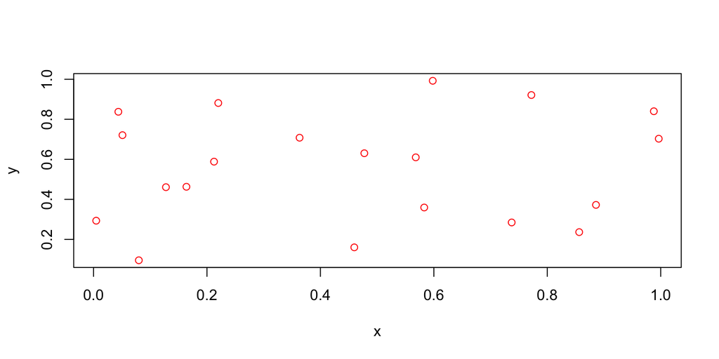

```r
red.plot <- function(x, y) {
  plot(x, y, col="red")
}

red.plot(runif(20), runif(20))
```

## Functions

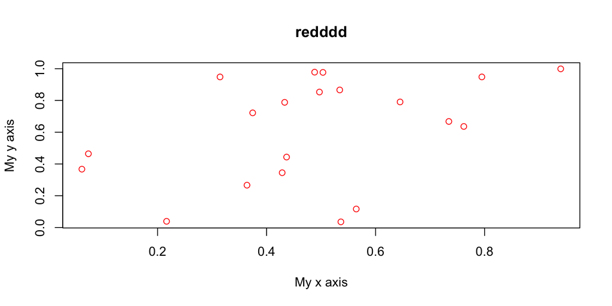

```r
red.plot <- function(x, y, ...) {
  plot(x, y, col="red", ...)
}

red.plot(runif(20), runif(20), xlab="My x axis", ylab="My y axis", main="redddd")
```

## Functions

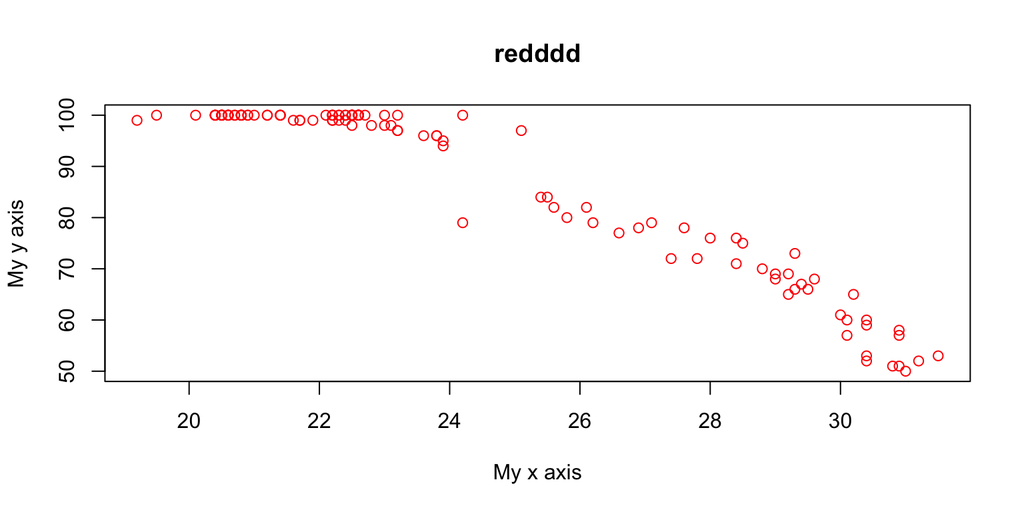

```r
red.plot <- function(x, y, ...) {
  plot(x, y, col="red", ...)
}

red.plot(sta1$temp, sta1$relative_humidity, xlab="My x axis", ylab="My y axis", main="redddd")
```

## Functions

```r
lets_guess <- function(x)
{
  n=28
  if(missing(x)) print("enter a value");
  if(x<0 | x>40) print("value must be 0<=x<=40)")
  else if(x<n) print("enter a higher value")
  else if(x>n) print("enter a lower value")
  else if(x==n) print(c("you got it ",x))
  else print("what are you doing? guess a number")
}
```

# String Manipulation

## String Manipulation

- grep()
- nchar()
- paste()
- sprintf()
- substr()
- strsplit()
- regex()
- gregexpr()

## String Manipulation

```r
grep("b+", c("abc", "bda", "cca a", "abd"))
```

```
## [1] 1 2 4
```

```r
str <- "Big Data at DataFlair"
nchar(str)
```

```
## [1] 21
```

```r
paste("Hadoop", "Spark", "and", "Flink")
```

```
## [1] "Hadoop Spark and Flink"
```

```r
paste("Hadoop", "Spark", "and", "Flink",sep = "")
```

```
## [1] "HadoopSparkandFlink"
```

## String Manipulation

```r
num <- "12345678"
substr(num, 4, 5)
```

```
## [1] "45"
```

```r
str = "Splitting sentence into words"
strsplit(str, " ")
```

```
## [[1]]
## [1] "Splitting" "sentence"  "into"      "words"
```

```r
strsplit(str, "i")
```

```
## [[1]]
## [1] "Spl"          "tt"           "ng sentence " "nto words"
```

## String Manipulation

```r
x <- "Learning To MANIPULATE strinGS in R"

tolower(x)
```

```
## [1] "learning to manipulate strings in r"
```

```r
toupper(x)
```

```
## [1] "LEARNING TO MANIPULATE STRINGS IN R"
```

```r
x <- "This is A string."

chartr(old = "A", new = "a", x)
```

```
## [1] "This is a string."
```

## String Manipulation

```r
y <- "Tomorrow I plzn do lezrn zbout dexduzl znzlysis."

chartr(old = "dz", new = "ta", y)
```

```
## [1] "Tomorrow I plan to learn about textual analysis."
```

```r
streets <- c("Main", "Elm", "Riverbend", "Mario", "Frederick")
abbreviate(streets)
```

```
##      Main       Elm Riverbend     Mario Frederick
##    "Main"     "Elm"    "Rvrb"    "Mari"    "Frdr"
```

```r
abbreviate(streets, minlength = 2)
```

```
##      Main       Elm Riverbend     Mario Frederick
##      "Mn"      "El"      "Rv"      "Mr"      "Fr"
```